# Cluster Report: Low Carbon London, 16 clusters

Universidad de Deusto (carlos.quesada@deusto.es)

2022-03-03 08:32:56

#### List of abbreviations

##### Sets of features

- **sAggrDRM**: seasonal aggregates v2.0 (day-referenced mean)
- **sAggrP6**: seasonal aggregates v3.0 (6-period time division)

##### Datasets

- **goi**: GoiEner (including Megara and La Corriente) [ES]
- **lcl**: Low Carbon London [GB]
- **iss**: Irish Social Science Data Archive (ISSDA) [IE]
- **por**: Elergone Energia [PT]
- **nee**: Northwest Energy Efficiency Alliance (NEEA) [US]
- **Nds**: N datasets put together

##### Clustering methods

- **som**: self-organizing maps

##### Statistic used

- **μ**: mean
- **σ**: standard deviation

## sAggrDRM > lcl > som

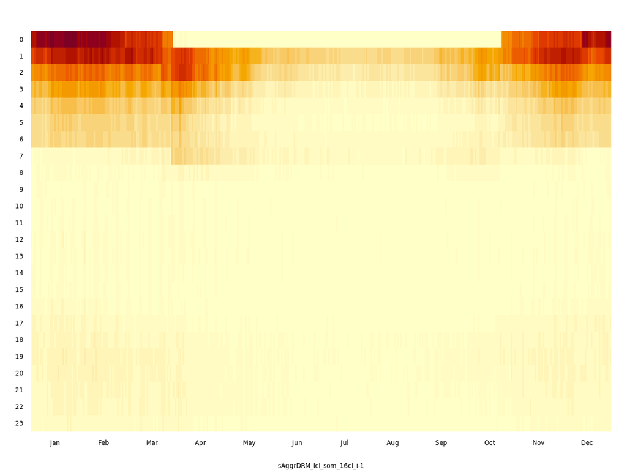

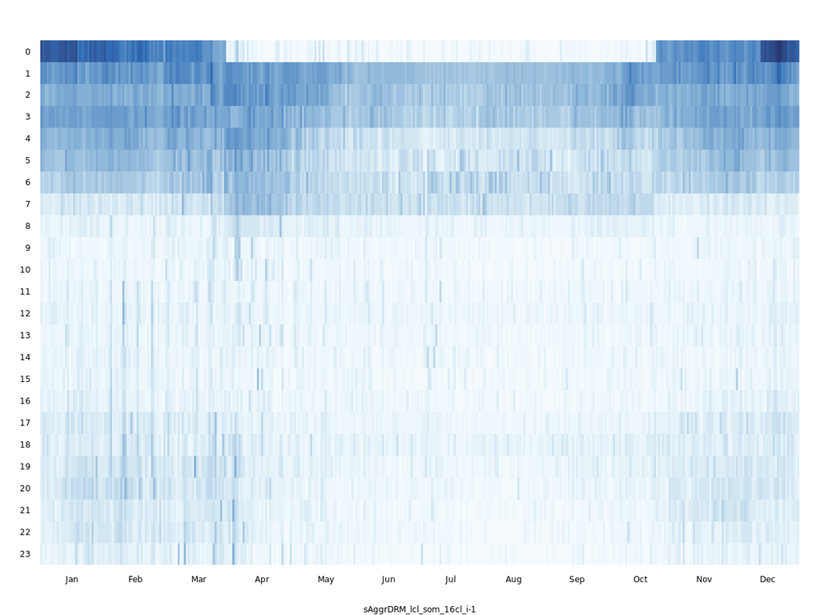

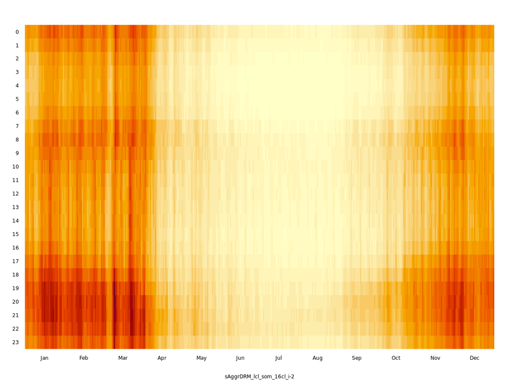

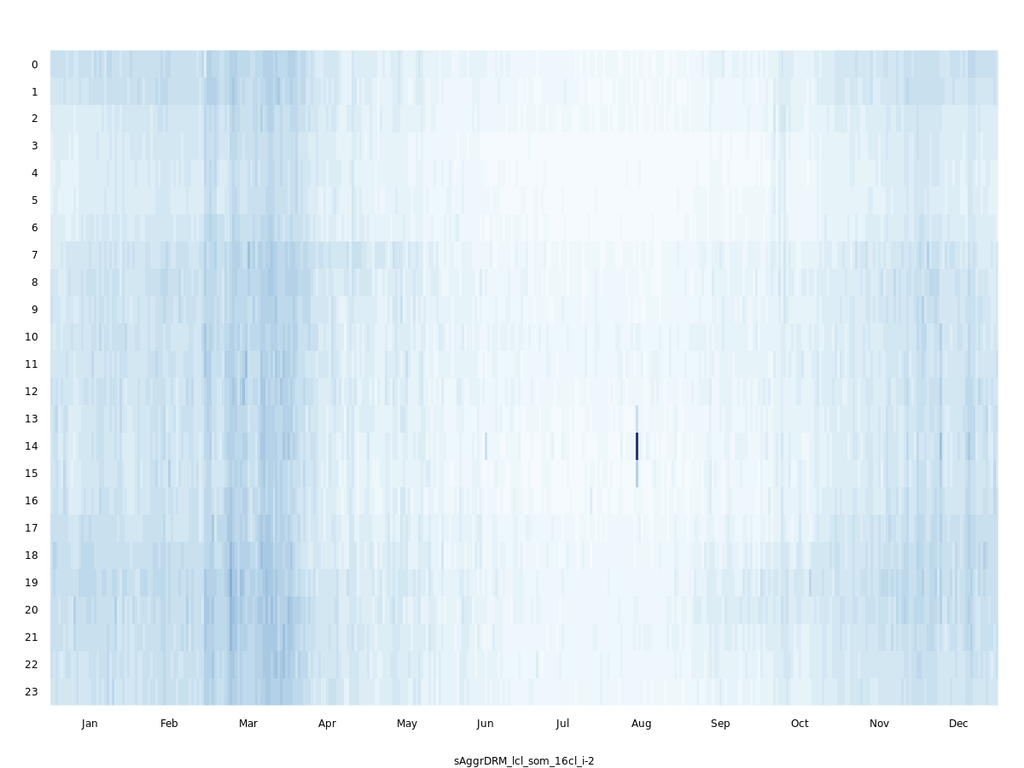

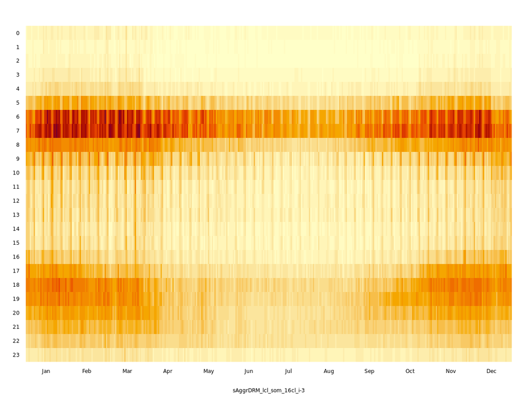

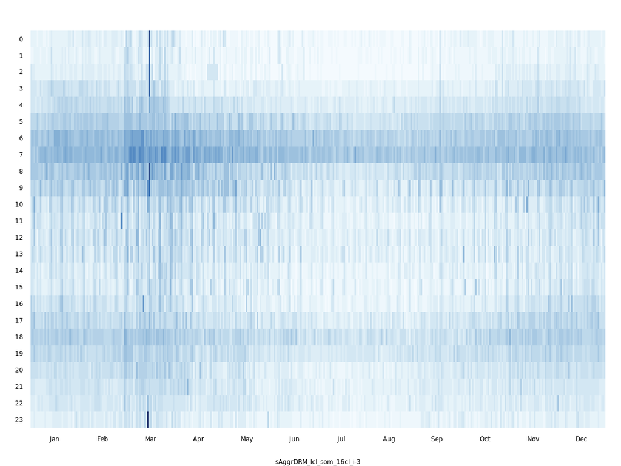

sAggrDRM > lcl > som > μ > #1

53 TS (1%)

sAggrDRM > lcl > som > σ > #1

53 TS (1%)

sAggrDRM > lcl > som > μ > #2

247 TS (4.7%)

sAggrDRM > lcl > som > σ > #2

247 TS (4.7%)

sAggrDRM > lcl > som > μ > #3

90 TS (1.7%)

sAggrDRM > lcl > som > σ > #3

90 TS (1.7%)

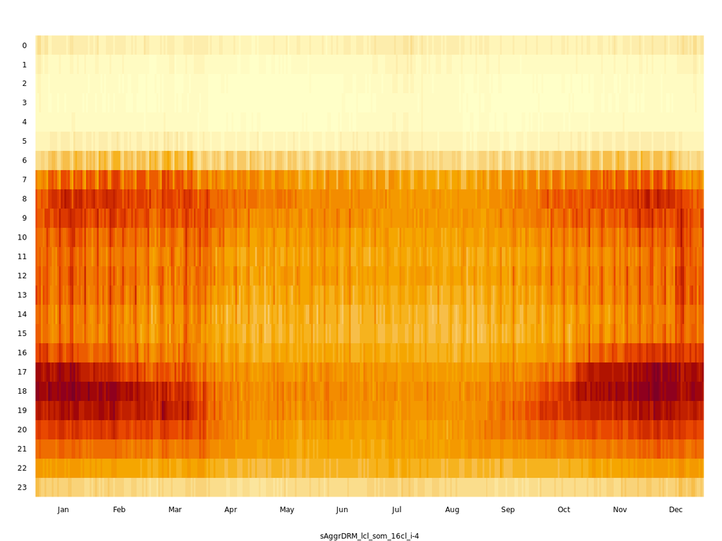

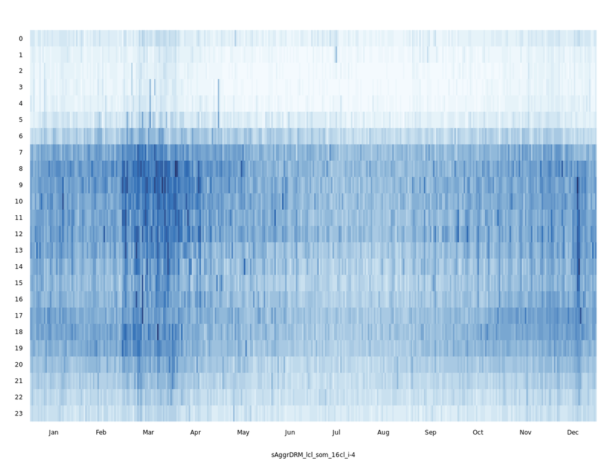

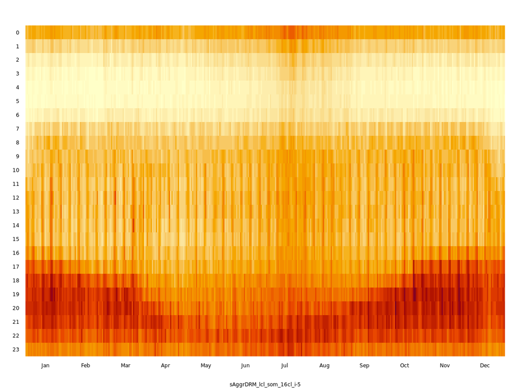

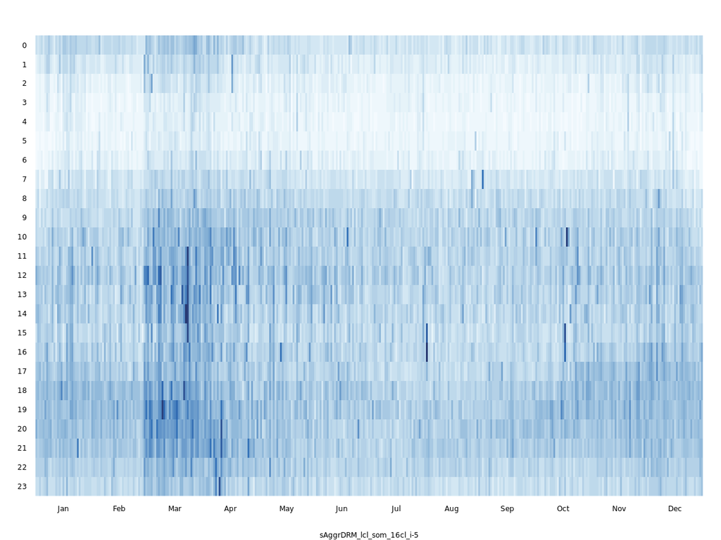

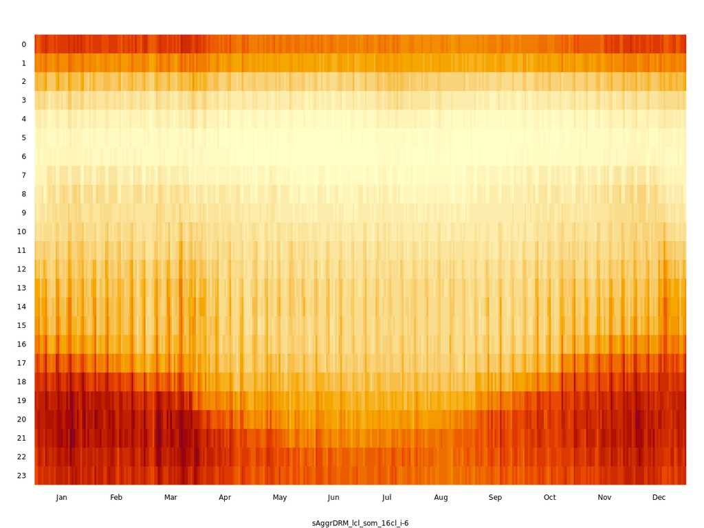

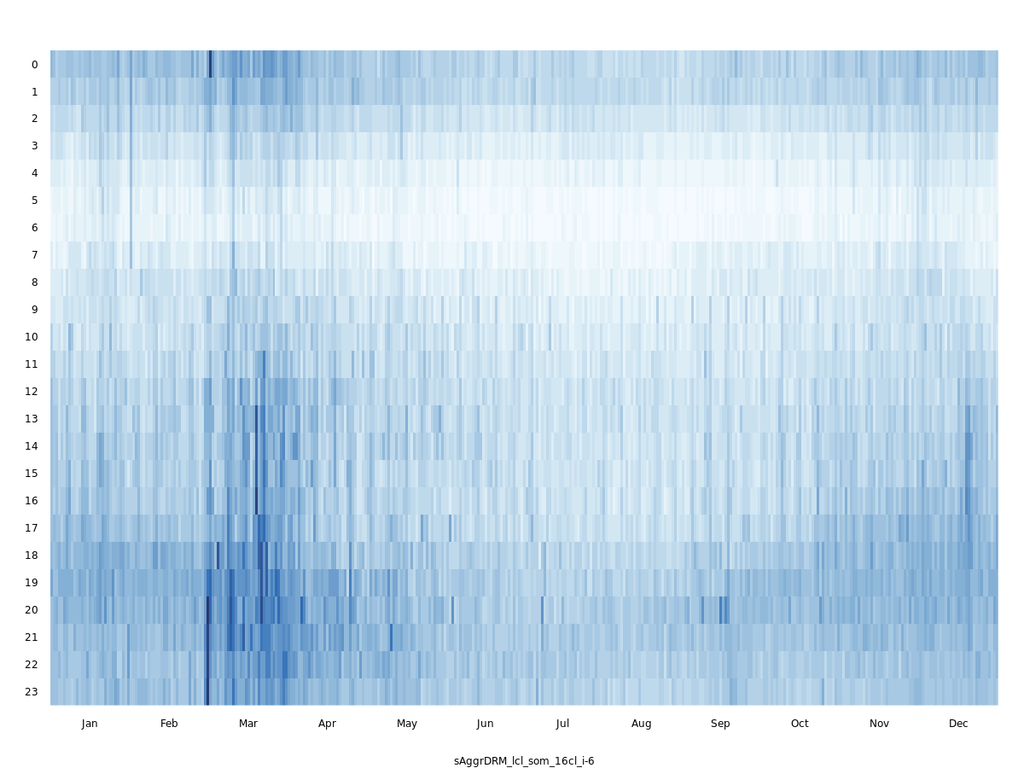

sAggrDRM > lcl > som > μ > #4

408 TS (7.8%)

sAggrDRM > lcl > som > σ > #4

408 TS (7.8%)

sAggrDRM > lcl > som > μ > #5

405 TS (7.7%)

sAggrDRM > lcl > som > σ > #5

405 TS (7.7%)

sAggrDRM > lcl > som > μ > #6

352 TS (6.7%)

sAggrDRM > lcl > som > σ > #6

352 TS (6.7%)

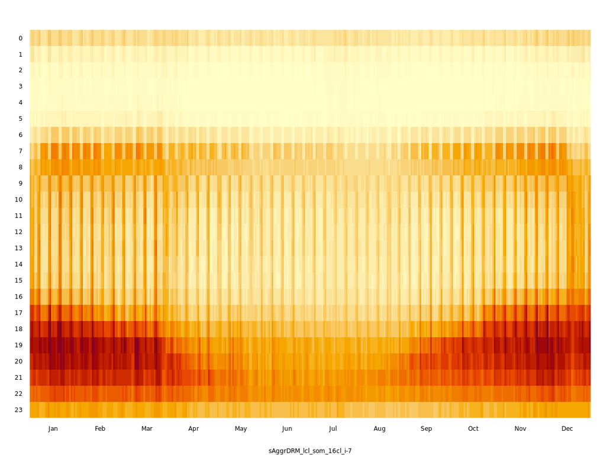

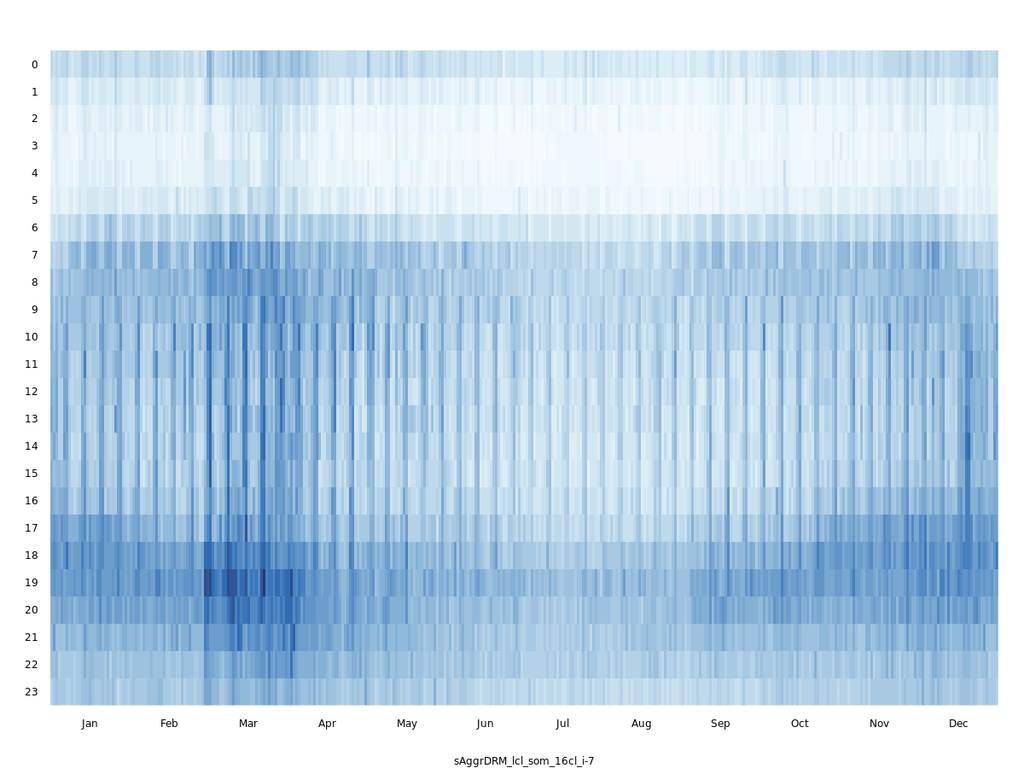

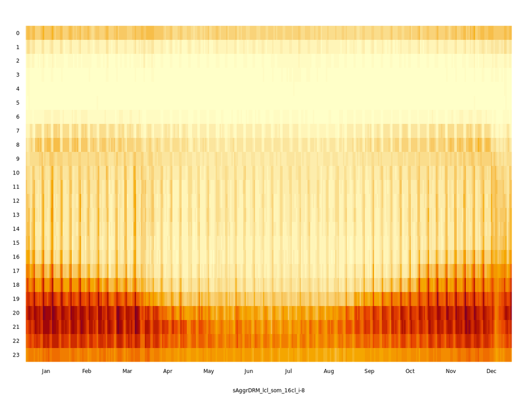

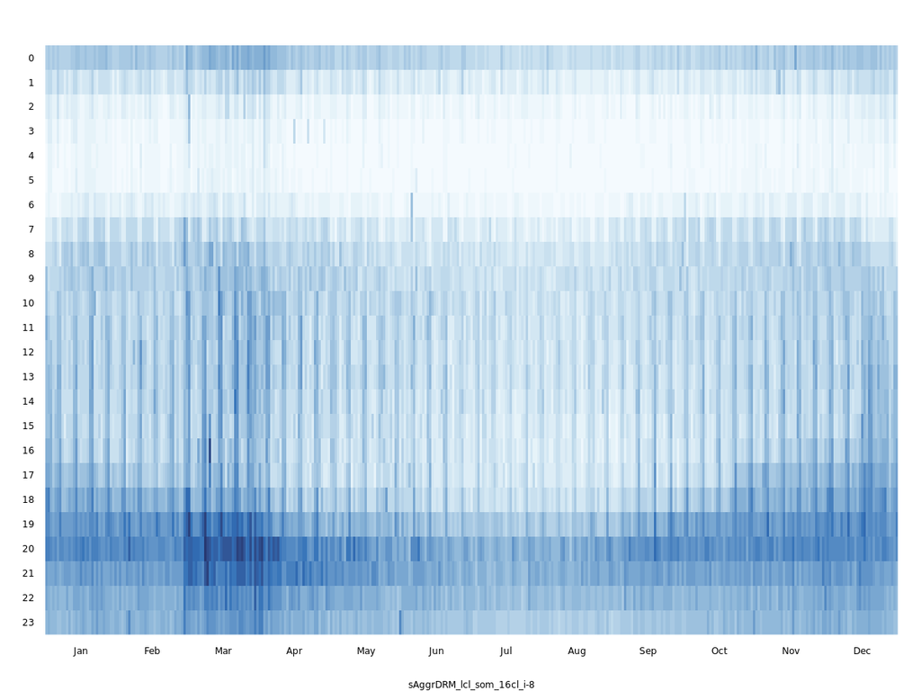

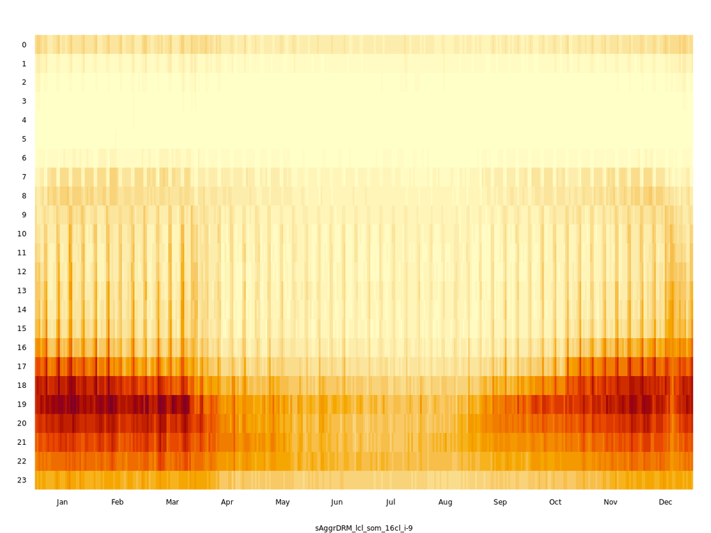

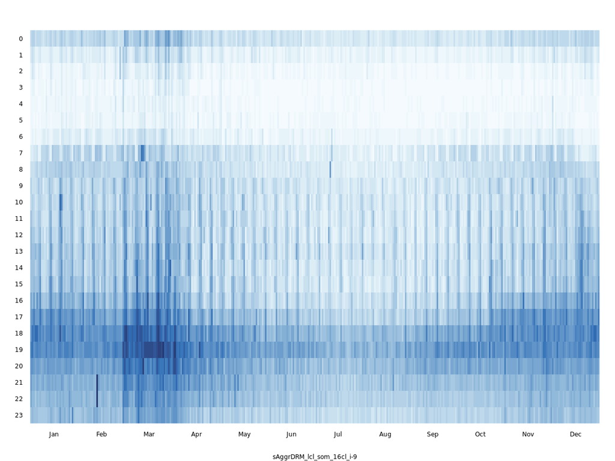

sAggrDRM > lcl > som > μ > #7

535 TS (10.2%)

sAggrDRM > lcl > som > σ > #7

535 TS (10.2%)

sAggrDRM > lcl > som > μ > #8

395 TS (7.5%)

sAggrDRM > lcl > som > σ > #8

395 TS (7.5%)

sAggrDRM > lcl > som > μ > #9

219 TS (4.2%)

sAggrDRM > lcl > som > σ > #9

219 TS (4.2%)

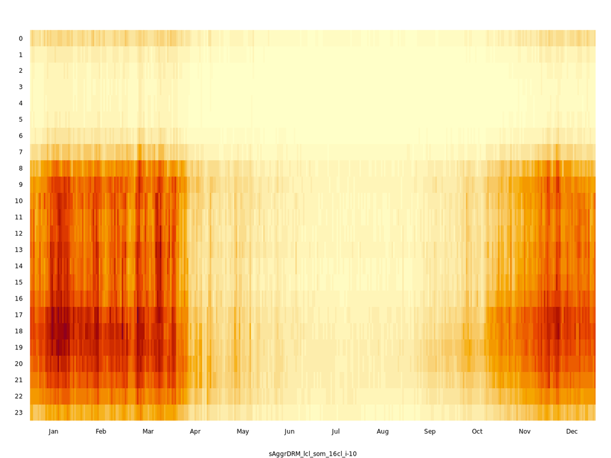

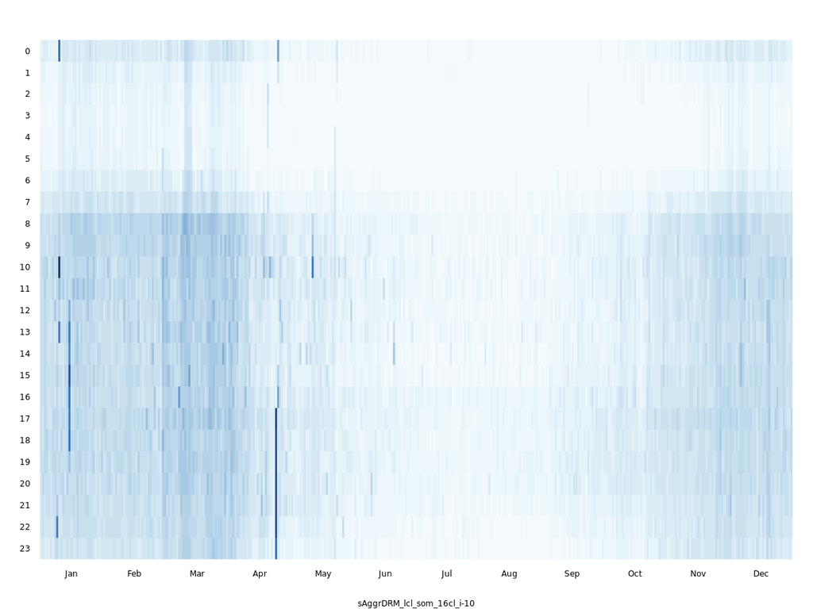

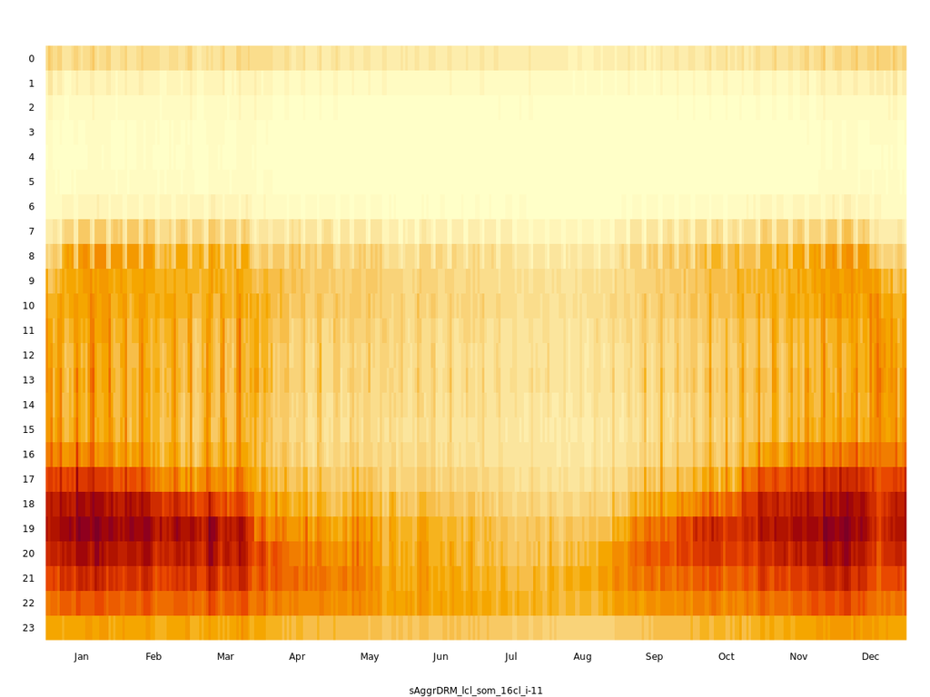

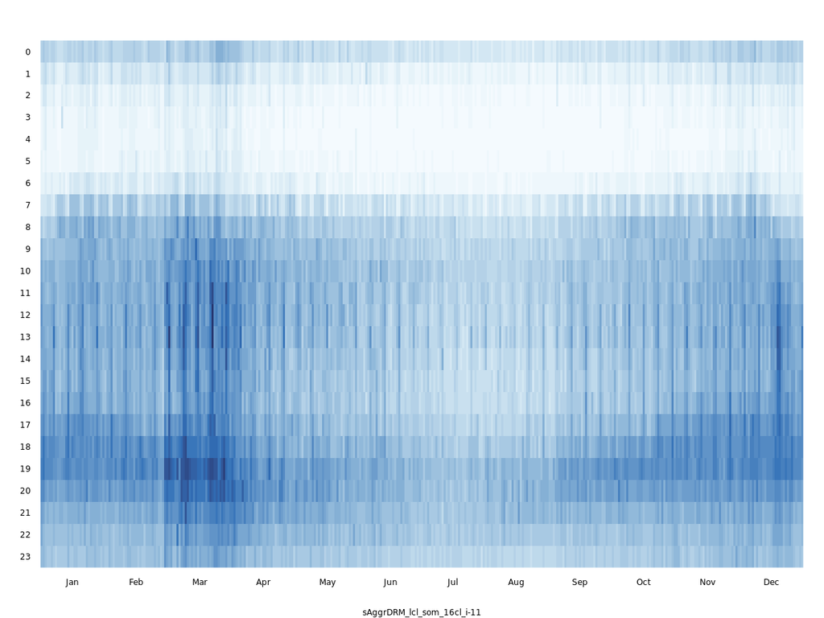

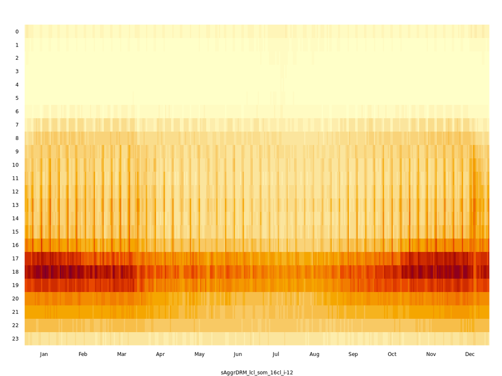

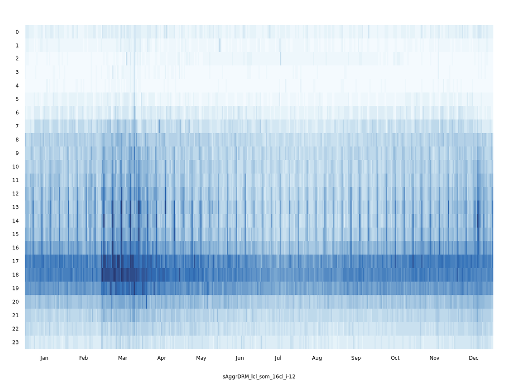

sAggrDRM > lcl > som > μ > #10

95 TS (1.8%)

sAggrDRM > lcl > som > σ > #10

95 TS (1.8%)

sAggrDRM > lcl > som > μ > #11

555 TS (10.6%)

sAggrDRM > lcl > som > σ > #11

555 TS (10.6%)

sAggrDRM > lcl > som > μ > #12

393 TS (7.5%)

sAggrDRM > lcl > som > σ > #12

393 TS (7.5%)

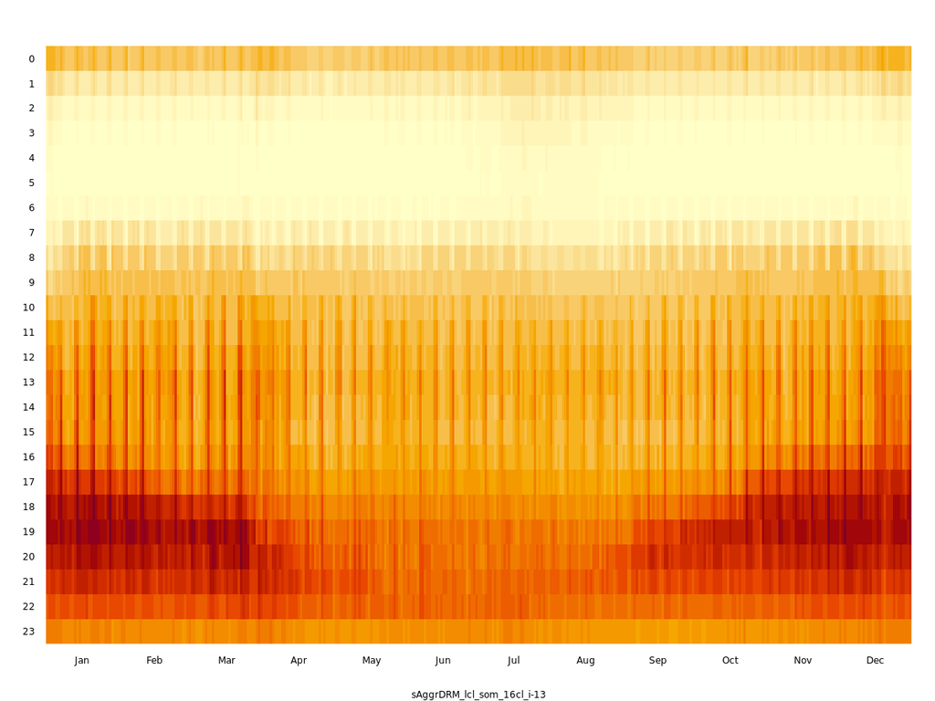

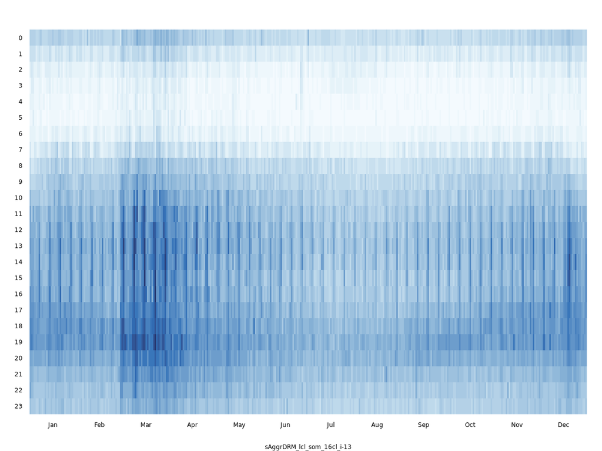

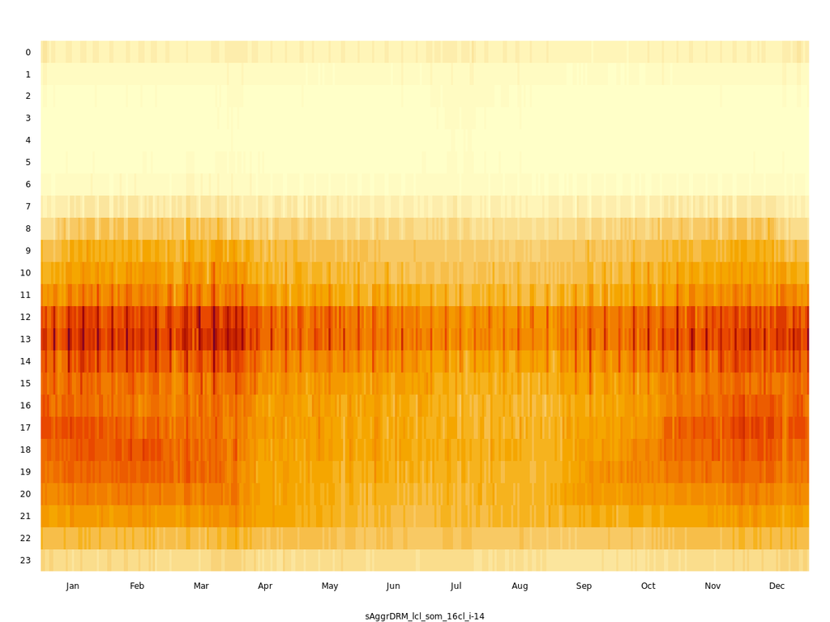

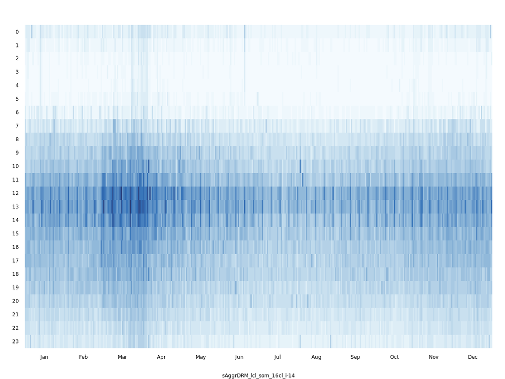

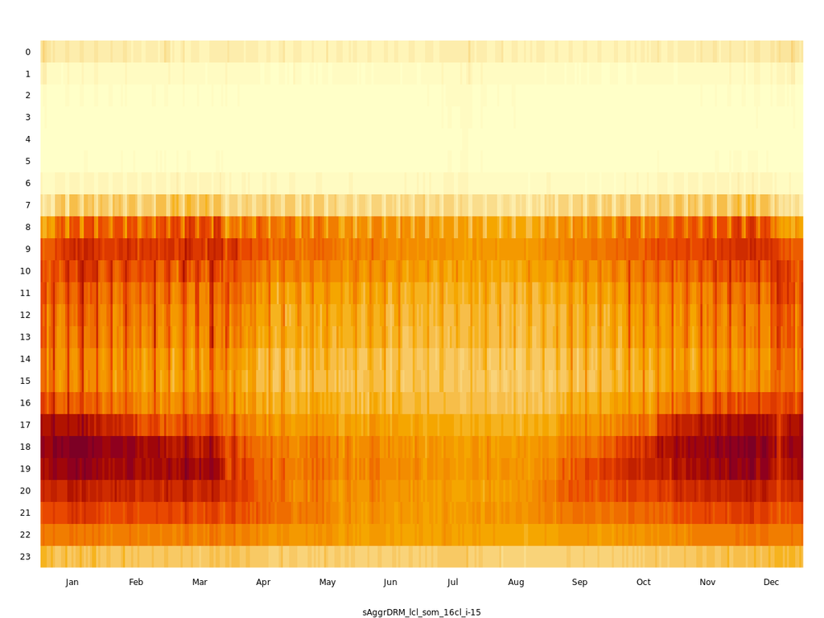

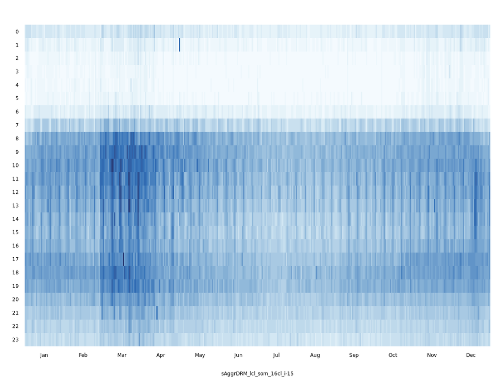

sAggrDRM > lcl > som > μ > #13

670 TS (12.8%)

sAggrDRM > lcl > som > σ > #13

670 TS (12.8%)

sAggrDRM > lcl > som > μ > #14

257 TS (4.9%)

sAggrDRM > lcl > som > σ > #14

257 TS (4.9%)

sAggrDRM > lcl > som > μ > #15

489 TS (9.3%)

sAggrDRM > lcl > som > σ > #15

489 TS (9.3%)

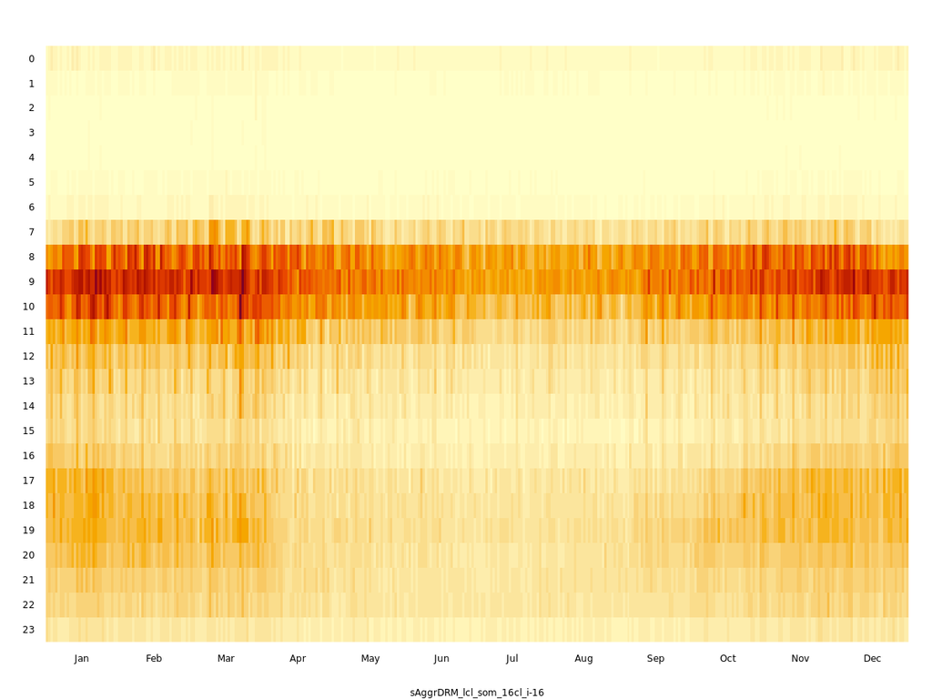

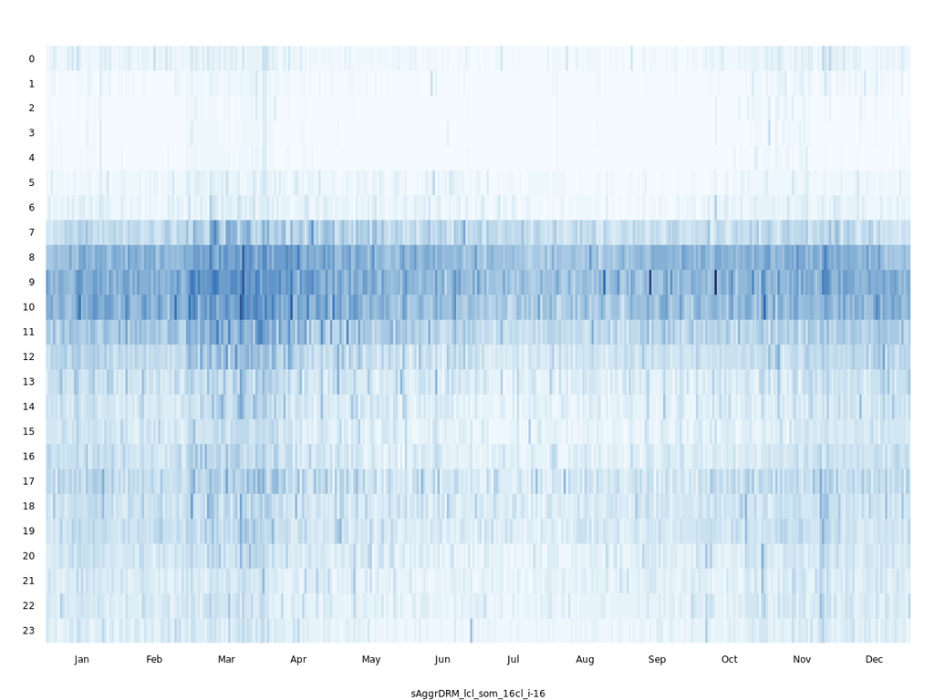

sAggrDRM > lcl > som > μ > #16

75 TS (1.4%)

sAggrDRM > lcl > som > σ > #16

75 TS (1.4%)